# Survive Before Go to Sea~

Atika Dewi Suryani

August 21, 2020

[figure not shown]

```r
knitr::include_graphics("image/intros.jfif")
```

# Library and Setup

```r
library(readr) # read data
library(caTools) # split datasets
library(dplyr)
library(forcats) # categorical variable
library(bbplot) # plot theme by bbc
library(ggplot2)
library(ggthemes)
library(InformationValue)
library(corrplot)
library(QuantPsyc)
library(caret)
library(randomForest)
library(adabag)
library(mice)
```

# Load and Inspect Data

The dataset is available on Kaggle website on this link: (https://www.kaggle.com/c/titanic)

**Variable Input**

**Survival**: 0 = No, 1 = Yes

**Pclass**: Ticket class (1 = 1st, 2 = 2nd, 3 = 3rd)

**Sex**: Sex of the passenger (female/male)

**Age**: Age in years (if the age is fractional, it is less than 1, if the age is estimated, it is in the form of xx.5)

**SibSp**: # of siblings (brother/sister/stepbrother/stepsister) or spouses (husband/wife) aboard

**ParCh**: # of parents (mother/father) or children (daughter/son/stepdaughter/stepson) aboard

**Ticket**: Ticket number

**Fare**: Passenger fare

**Cabin**: Cabin number

**Embarked**: Port of Embarkation (C = Cherbourg, Q = Queenstown, S = Southampton)

## Inspect Data

```r
dim(train) # 891 rows, 12 columns
```

```
## [1] 891  12
```

```r
dim(test) # 418 rows, 11 columns
```

```
## [1] 418  11
```

In this section, I will utilize the idea of feature engineering, basically try to create additional relevent features from the existing raw features in the data, and to increase the predictive power of the learning algorithms.

## Merge dataset

Now, I merged the independent variables of training and test sets into a full data set, which is convenient for me to manipulate the data on both sets.

```r
full_data <- rbind(train[,-c(1,2)], test[,-1])

summary(full_data)
```

```
##      Pclass          Name               Sex                 Age
##  Min.   :1.000   Length:1309        Length:1309        Min.   : 0.17
##  1st Qu.:2.000   Class :character   Class :character   1st Qu.:21.00
##  Median :3.000   Mode  :character   Mode  :character   Median :28.00
##  Mean   :2.295                                         Mean   :29.88
##  3rd Qu.:3.000                                         3rd Qu.:39.00
##  Max.   :3.000                                         Max.   :80.00
##                                                        NA's   :263
##      SibSp            Parch          Ticket               Fare
##  Min.   :0.0000   Min.   :0.000   Length:1309        Min.   :  0.000
##  1st Qu.:0.0000   1st Qu.:0.000   Class :character   1st Qu.:  7.896
##  Median :0.0000   Median :0.000   Mode  :character   Median : 14.454
##  Mean   :0.4989   Mean   :0.385                      Mean   : 33.295
##  3rd Qu.:1.0000   3rd Qu.:0.000                      3rd Qu.: 31.275
##  Max.   :8.0000   Max.   :9.000                      Max.   :512.329
##                                                      NA's   :1
##     Cabin             Embarked
##  Length:1309        Length:1309
##  Class :character   Class :character
##  Mode  :character   Mode  :character
##
##
##
##
```

# Data Manipulation

## PcClass

Based on the description of the Data in Part2, Pclass is an ordered factor variable, therefore, I will transform it from a numeric variable to a categorical variable.

```r
full_data$Pclass <- factor(full_data$Pclass,
                                 levels = c("3", "2", "1"),
                                 labels = c("3rd", "2nd", "1st"),
                                 ordered = T)

table(full_data$Pclass)
```

```
##
## 3rd 2nd 1st
## 709 277 323
```

## Age

```r
full_data <- full_data %>%
  mutate(Age_Category = case_when(
    Age < 13 ~ "Child",
    between(Age, 13, 18) ~ "Teenager",
    between(Age, 19, 50) ~ "Adult",
    Age > 50 ~ "Old"
  ))
```

## Passenger

Extract the title from name to support further analysis.

```r
full_data$Title <-  gsub("^.*, (.*?)\\..*$", "\\1", full_data$Name)
table(full_data$Title)
```

```
##
##         Capt          Col          Don         Dona           Dr     Jonkheer
##            1            4            1            1            8            1
##         Lady        Major       Master         Miss         Mlle          Mme
##            1            2           61          260            2            1
##           Mr          Mrs           Ms          Rev          Sir the Countess
##          757          197            2            8            1            1
```

Based on the result above, the `most frequent` variables are `“Master”, “Miss”, “Mr”, and “Mrs”`. Therefore, I will explore the observations with rare titles and check if I could `group them into the 4 most frequent titles`.

```r
full_data %>%
            filter(!Title %in% c("Master", "Miss", "Mr", "Mrs")) %>%
            select_all()%>%
            arrange(Sex)
```

```
## # A tibble: 34 x 12
##    Pclass Name  Sex     Age SibSp Parch Ticket   Fare Cabin Embarked
##    <ord>  <chr> <chr> <dbl> <dbl> <dbl> <chr>   <dbl> <chr> <chr>
##  1 1st    "Aub~ fema~    24     0     0 PC 17~  69.3  B35   C
##  2 2nd    "Rey~ fema~    28     0     0 230434  13    <NA>  S
##  3 1st    "Duf~ fema~    48     1     0 11755   39.6  A16   C
##  4 1st    "Sag~ fema~    24     0     0 PC 17~  69.3  B35   C
##  5 1st    "May~ fema~    24     0     0 PC 17~  49.5  C90   C
##  6 1st    "Rot~ fema~    33     0     0 110152  86.5  B77   S
##  7 1st    "Lea~ fema~    49     0     0 17465   25.9  D17   S
##  8 3rd    "O'D~ fema~    NA     0     0 364856   7.75 <NA>  Q
##  9 1st    "Oli~ fema~    39     0     0 PC 17~ 109.   C105  C
## 10 1st    "Uru~ male     40     0     0 PC 17~  27.7  <NA>  C
## # ... with 24 more rows, and 2 more variables: Age_Category <chr>, Title <chr>
```

Categorise title and merge them back again into 4 big category

```r
full_data <- full_data %>%
  mutate(Title = fct_collapse(Title,
                              "Miss" = c("Miss", "Ms", "Lady", "Mlle", "Mme"),
                              "Mr" = c("Mr", "Sir"),
                              "Mrs" = "Mrs",
                              "Master" = "Master",
                              )) %>%
  mutate(Title = fct_other(Title, keep = c("Miss", "Mr", "Mrs", "Master"), other_level = "Unordinary"))

table(full_data$Title)
```

```
##
##       Miss     Master         Mr        Mrs Unordinary
##        266         61        758        197         27
```

## FamilySize

Since `siblings, spouse, parents, children` all `express family size` information, I add a new categorical variable **FamilySize** to display this information.

```r
table(full_data$SibSp)
```

```
##
##   0   1   2   3   4   5   8
## 891 319  42  20  22   6   9
```

```r
full_data <- full_data %>%
              mutate(FamilySize = SibSp + Parch + 1,) %>%
              mutate(FamilySize_Cat = case_when(
              FamilySize == 1 ~ "Single",
              between(FamilySize, 2, 4) ~ "Small",
              FamilySize >= 5 ~ "Large"
              )) %>%
              mutate(FamilySize_Cat = fct_relevel(FamilySize_Cat,
              "Single", "Small", "Large"))

table(full_data$FamilySize_Cat)
```

```
##
## Single  Small  Large
##    790    437     82
```

## TicketType

For Ticket variable, it’s similary as Name variable, meaning that we could not directly extract useful information from it. However, I found that `sometimes the ticket number only shows once, while other times, ticket numbers shows multiple times`. Therefore, I will `add a new categorical` variable named `**TicketType** that shows the frequency of the Ticket number.

```r
ticket.unique <- rep(0, nrow(full_data))
tickets <- unique(full_data$Ticket) # list each unique the Ticket number 1 time

for (i in 1:length(tickets)) {
            current.ticket <- tickets[i]
            party.indexes <- which(full_data$Ticket == current.ticket)

for (k in 1:length(party.indexes)) {
            ticket.unique[party.indexes[k]] <- length(party.indexes)
            }
}

full_data <- full_data %>%
              mutate(TicketGroup = ticket.unique,) %>%
              mutate(TicketType = case_when(
              TicketGroup == 1 ~ "Single",
              between(TicketGroup, 2, 4) ~ "Small",
              TicketGroup >= 5 ~ "Large"
              )) %>%
              mutate(TicketType = fct_relevel(TicketType, "Single", "Small", "Large"))

table(full_data$TicketGroup)
```

```
##
##   1   2   3   4   5   6   7   8  11
## 713 264 147  64  35  24  35  16  11
```

```r
table(full_data$TicketType)
```

```
##
## Single  Small  Large
##    713    475    121
```

# Data Cleaning

## Fill in Age

```r
set.seed(1234)
mice.mod <- mice(full_data[, !names(full_data) %in% c("Name", "SibSp", "Parch", "Ticket", "Cabin")], method = "pmm")
mice.output <- complete(mice.mod)
```

Now, check the distribution of Age before and after the imputation. The two distributions are highly similar to each other, therefore, it’s an valid method to utilize.

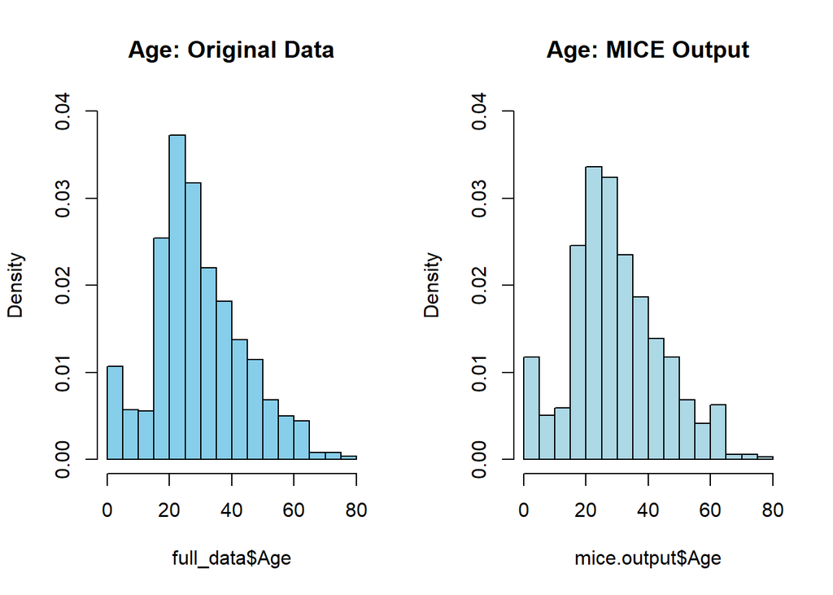

```r
par(mfrow = c(1,2))
hist(full_data$Age, freq = F, main = "Age: Original Data",
     col='skyblue', ylim=c(0,0.04))
hist(mice.output$Age, freq = F, main = "Age: MICE Output",
     col='lightblue', ylim=c(0, 0.04))
```

Embed the data on `full_data-Age`

```r
par(mfrow=c(1,1))

full_data$Age <- mice.output$Age

colSums(is.na(full_data))
```

```
##         Pclass           Name            Sex            Age          SibSp
##              0              0              0              0              0
##          Parch         Ticket           Fare          Cabin       Embarked
##              0              0              1           1014              2
##   Age_Category          Title     FamilySize FamilySize_Cat    TicketGroup
##            266              0              0              0              0
##     TicketType
##              0
```

The idea of binning the Age variable is that I believe children and the old people are more likely to be saved, resulting higher survival rate.

```r
full_data <- full_data %>%
              mutate(Age_Category = case_when(
              Age <= 17 ~ "Child",
              between(Age, 17, 18) ~ "Teenager",
              between(Age, 19, 50) ~ "Adult",
              Age > 50 ~ "Old"
              ))

table(full_data$Age_Category)
```

```
##
##    Adult    Child      Old Teenager
##      938      189      123       56
```

```r
full_data %>%
  mutate(Age_Category=as.factor(Age_Category)) %>%
  group_by(Age_Category) %>%
  filter(Age_Category == "NA")
```

```
## # A tibble: 0 x 16
## # Groups:   Age_Category [0]
## # ... with 16 variables: Pclass <ord>, Name <chr>, Sex <chr>, Age <dbl>,
## #   SibSp <dbl>, Parch <dbl>, Ticket <chr>, Fare <dbl>, Cabin <chr>,
## #   Embarked <chr>, Age_Category <fct>, Title <fct>, FamilySize <dbl>,
## #   FamilySize_Cat <fct>, TicketGroup <dbl>, TicketType <fct>
```

```r
colSums(is.na(full_data))
```

```
##         Pclass           Name            Sex            Age          SibSp
##              0              0              0              0              0
##          Parch         Ticket           Fare          Cabin       Embarked
##              0              0              1           1014              2
##   Age_Category          Title     FamilySize FamilySize_Cat    TicketGroup
##              3              0              0              0              0
##     TicketType
##              0
```

## Fill in Fare

First, figure out the observation with missing value.

```r
full_data %>%
  filter(is.na(Fare))
```

```
## # A tibble: 1 x 16
##   Pclass Name  Sex     Age SibSp Parch Ticket  Fare Cabin Embarked Age_Category
##   <ord>  <chr> <chr> <dbl> <dbl> <dbl> <chr>  <dbl> <chr> <chr>    <chr>
## 1 3rd    Stor~ male   60.5     0     0 3701      NA <NA>  S        Old
## # ... with 5 more variables: Title <fct>, FamilySize <dbl>,
## #   FamilySize_Cat <fct>, TicketGroup <dbl>, TicketType <fct>
```

```r
full_data %>%
  group_by(Pclass, Embarked) %>%
  summarise(median = median(Fare, na.rm = T)) %>%
  ungroup()
```

```
## # A tibble: 10 x 3
##    Pclass Embarked median
##    <ord>  <chr>     <dbl>
##  1 3rd    C          7.90
##  2 3rd    Q          7.75
##  3 3rd    S          8.05
##  4 2nd    C         15.3
##  5 2nd    Q         12.4
##  6 2nd    S         15.4
##  7 1st    C         76.7
##  8 1st    Q         90
##  9 1st    S         52
## 10 1st    <NA>      80
```

```r
colSums(is.na(full_data))
```

```
##         Pclass           Name            Sex            Age          SibSp
##              0              0              0              0              0
##          Parch         Ticket           Fare          Cabin       Embarked
##              0              0              1           1014              2
##   Age_Category          Title     FamilySize FamilySize_Cat    TicketGroup
##              3              0              0              0              0
##     TicketType
##              0
```

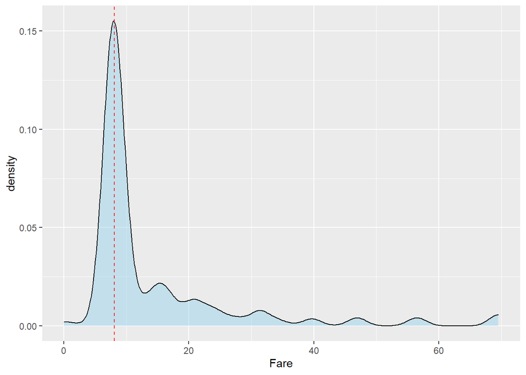

```r
# visualization
full_data %>%
  filter(Pclass == "3rd", Embarked == "S") %>%
  ggplot(aes(x = Fare)) +
  geom_density(fill = "skyblue", alpha = 0.4) +
  geom_vline(aes(xintercept = median(Fare, na.rm =  T)),
             col = "red", linetype = 2, size = 0.5)
```

Based on plot, we have median around `8,05`

```r
# fill in  the missing value using median
full_data$Fare[is.na(full_data$Fare)] <- 8.05
```

## Drop Cabin

As we know, Cabin has 1014 missing values, meaning that more than 75% of the information was missed. Therefore, I simply deleted this variable.

```r
full_data$Cabin <- NULL

colSums(is.na(full_data))
```

```
##         Pclass           Name            Sex            Age          SibSp
##              0              0              0              0              0
##          Parch         Ticket           Fare       Embarked   Age_Category
##              0              0              0              2              3
##          Title     FamilySize FamilySize_Cat    TicketGroup     TicketType
##              0              0              0              0              0
```

## Fill in Embarked

First, figure out the observation with missing value.

```r
full_data %>%
  filter(is.na(Embarked))
```

```
## # A tibble: 2 x 15
##   Pclass Name  Sex     Age SibSp Parch Ticket  Fare Embarked Age_Category Title
##   <ord>  <chr> <chr> <dbl> <dbl> <dbl> <chr>  <dbl> <chr>    <chr>        <fct>
## 1 1st    Icar~ fema~    38     0     0 113572    80 <NA>     Adult        Miss
## 2 1st    Ston~ fema~    62     0     0 113572    80 <NA>     Old          Mrs
## # ... with 4 more variables: FamilySize <dbl>, FamilySize_Cat <fct>,
## #   TicketGroup <dbl>, TicketType <fct>
```

For these two observations, both of them were in the 1st class and their Fare prices were both 80.

Then, show the table of median Fare values sliced by Pclass and Embarked again:

```r
full_data %>%
  group_by(Pclass, Embarked) %>%
  summarise(median = median(Fare, na.rm = T))
```

```
## # A tibble: 10 x 3
## # Groups:   Pclass [3]
##    Pclass Embarked median
##    <ord>  <chr>     <dbl>
##  1 3rd    C          7.90
##  2 3rd    Q          7.75
##  3 3rd    S          8.05
##  4 2nd    C         15.3
##  5 2nd    Q         12.4
##  6 2nd    S         15.4
##  7 1st    C         76.7
##  8 1st    Q         90
##  9 1st    S         52
## 10 1st    <NA>      80
```

Based on the result, it’s not hard to find that the median Fare price of passengers Embarked on C and were in the 1st class is 76.7, which is quite similar to 80. Therefore, it’s safe to fill in the missing value of Embarked information as “C” as below.

```r
full_data$Embarked[which(is.na(full_data$Embarked))] <- 'C'
table(full_data$Embarked) # double check
```

```
##
##   C   Q   S
## 272 123 914
```

```r
# there's an unused level, therefore, drop it as below:
full_data$Embarked<- as.factor(full_data$Embarked)
full_data$Embarked <- droplevels(full_data$Embarked)
```

## Finalising

```r
full_data <- full_data %>%
  select_all()

str(full_data)
```

```
## tibble [1,309 x 15] (S3: tbl_df/tbl/data.frame)
##  $ Pclass        : Ord.factor w/ 3 levels "3rd"<"2nd"<"1st": 1 3 1 3 1 1 3 1 1 2 ...
##  $ Name          : chr [1:1309] "Braund, Mr. Owen Harris" "Cumings, Mrs. John Bradley (Florence Briggs Thayer)" "Heikkinen, Miss. Laina" "Futrelle, Mrs. Jacques Heath (Lily May Peel)" ...
##  $ Sex           : chr [1:1309] "male" "female" "female" "female" ...
##  $ Age           : num [1:1309] 22 38 26 35 35 31 54 2 27 14 ...
##  $ SibSp         : num [1:1309] 1 1 0 1 0 0 0 3 0 1 ...
##  $ Parch         : num [1:1309] 0 0 0 0 0 0 0 1 2 0 ...
##  $ Ticket        : chr [1:1309] "A/5 21171" "PC 17599" "STON/O2. 3101282" "113803" ...
##  $ Fare          : num [1:1309] 7.25 71.28 7.92 53.1 8.05 ...
##  $ Embarked      : Factor w/ 3 levels "C","Q","S": 3 1 3 3 3 2 3 3 3 1 ...
##  $ Age_Category  : chr [1:1309] "Adult" "Adult" "Adult" "Adult" ...
##  $ Title         : Factor w/ 5 levels "Miss","Master",..: 3 4 1 4 3 3 3 2 4 4 ...
##  $ FamilySize    : num [1:1309] 2 2 1 2 1 1 1 5 3 2 ...
##  $ FamilySize_Cat: Factor w/ 3 levels "Single","Small",..: 2 2 1 2 1 1 1 3 2 2 ...
##  $ TicketGroup   : num [1:1309] 1 2 1 2 1 1 2 5 3 2 ...
##  $ TicketType    : Factor w/ 3 levels "Single","Small",..: 1 2 1 2 1 1 2 3 2 2 ...
```

## Summary

# Exploratory Data Analysis

## Split Data Train-Test

Cleaned train and test data sets and perform EDA on the train dataset, because we only have the Survived information of the train dataset.

```r
train.clean <- cbind(train$Survived, full_data[1:891,])
names(train.clean)[1] <- "Survived"
train.clean$Survived <- as.factor(train.clean$Survived)

test.clean <- full_data[892:1309,]
```

# Effect Independent on Dependent Variables

## PcClass

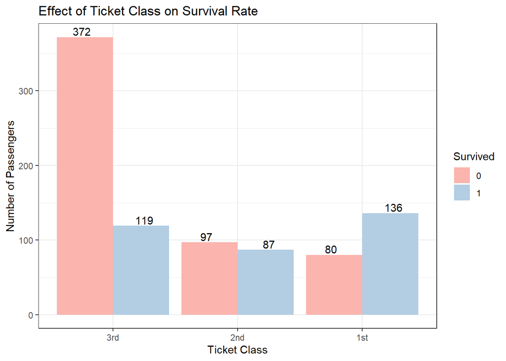

```r
train.clean %>%
  ggplot(aes(x = Pclass, y = ..count.., fill = Survived)) +
  geom_bar(stat = "count", position = "dodge") +
  labs(x = "Ticket Class",
       y = "Number of Passengers",
       title = "Effect of Ticket Class on Survival Rate") +
  theme_bw() + scale_fill_brewer(palette = "Pastel1") +
  geom_text(stat = "count",
            aes(label = ..count..),
            position=position_dodge(width = 1),
            vjust=-0.2)
```

**Summary** Based on the visualization, more than 50% the passengers in the 1st class survived, about 50% of the passengers in the 2nd class survived, while most of the passenger in the 3rd class did not survive.

Next, calculate WOE and IV as below:

```r
# library(InformationValue)
WOETable(X = train.clean$Pclass, Y = train.clean$Survived)
```

```
##   CAT GOODS BADS TOTAL     PCT_G     PCT_B        WOE         IV
## 1 3rd   119  372   491 0.3479532 0.6775956 -0.6664827 0.21970095
## 2 2nd    87   97   184 0.2543860 0.1766849  0.3644848 0.02832087
## 3 1st   136   80   216 0.3976608 0.1457195  1.0039160 0.25292792
```

```r
IV(X = train.clean$Pclass, Y = train.clean$Survived)
```

```
## [1] 0.5009497
## attr(,"howgood")
## [1] "Highly Predictive"
```

According to a `0.5 IV value`, and the `Highly Predictive` result, we could regard `Pclass` as one of the features that are `used to model the data`.

## Passenger

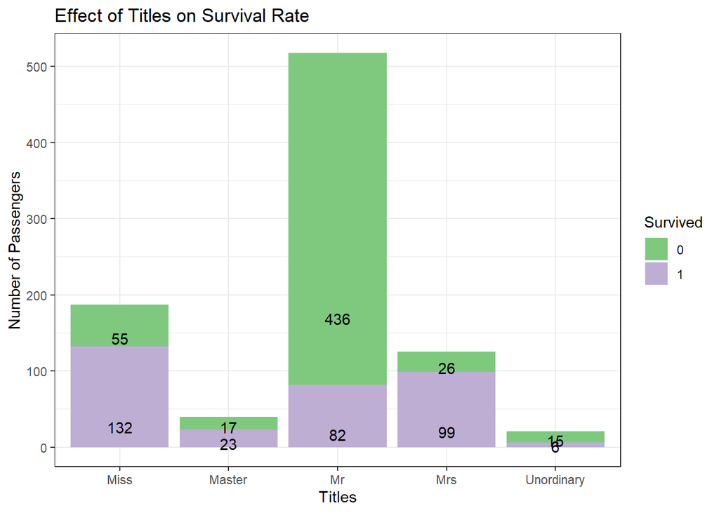

```r
train.clean %>%
  ggplot(aes(x = Title, y = ..count.., fill = Survived)) +
  geom_bar(stat = "count", position = "stack") +
  labs(x = "Titles",
       y = "Number of Passengers",
       title = "Effect of Titles on Survival Rate") +
  theme_bw() + scale_fill_brewer(palette = "Accent") +
  geom_text(stat = "count",
            aes(label = ..count..),
            position = position_stack(vjust = 0.2))
```

**Summary** According to the plot, most of the passengers with the title of “Mr” did not survive, while passengers with the title of “Miss” and “Mrs” have higher survival rate.

Next, calculate WOE and IV as below:

```r
WOETable(X = train.clean$Title, Y = train.clean$Survived)
```

```
##          CAT GOODS BADS TOTAL      PCT_G      PCT_B        WOE          IV
## 1       Miss   132   55   187 0.38596491 0.10018215  1.3487564 0.385451342
## 2     Master    23   17    40 0.06725146 0.03096539  0.7755686 0.028142336
## 3         Mr    82  436   518 0.23976608 0.79417122 -1.1976353 0.663975160
## 4        Mrs    99   26   125 0.28947368 0.04735883  1.8103110 0.438303180
## 5 Unordinary     6   15    21 0.01754386 0.02732240 -0.4430030 0.004331925
```

```r
IV(X = train.clean$Title, Y = train.clean$Survived)
```

```
## [1] 1.520204
## attr(,"howgood")
## [1] "Highly Predictive"
```

The IV value is as `high as 1.52`, therefore, `we could regard Title as one of the features that are used to model the data`.

## Sex

Next, calculate WOE and IV as below:

```r
WOETable(X = as.factor(train.clean$Sex), Y = train.clean$Survived)
```

```
##      CAT GOODS BADS TOTAL     PCT_G    PCT_B        WOE        IV
## 1 female   233   81   314 0.6812865 0.147541  1.5298770 0.8165651
## 2   male   109  468   577 0.3187135 0.852459 -0.9838327 0.5251163
```

```r
IV(X = as.factor(train.clean$Sex), Y = train.clean$Survived)
```

```
## [1] 1.341681
## attr(,"howgood")
## [1] "Highly Predictive"
```

The IV value is as high as 1.34, therefore, we could regard Sex as one of the features that are used to model the data.

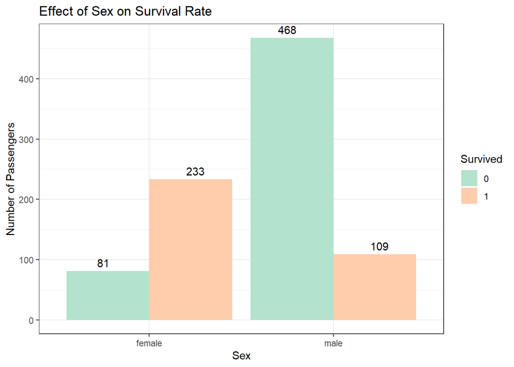

```r
train.clean %>%
  ggplot(aes(x = Sex, y = ..count.., fill = Survived)) +
  geom_bar(stat = "count", position = "dodge") +
  labs(x = "Sex",
       y = "Number of Passengers",
       title = "Effect of Sex on Survival Rate") +
  theme_bw() + scale_fill_brewer(palette = "Pastel2") +
  geom_text(stat = "count",
            aes(label = ..count..),
            position = position_dodge(width = 1), vjust = -0.5)
```

**Summary** According to the plot, female passengers are much morel likely to survive than male passengers.

## Age

```r
WOETable(X = as.factor(train.clean$Age), Y = train.clean$Survived)
```

```
##     CAT GOODS BADS TOTAL       PCT_G       PCT_B         WOE           IV
## 1  0.17     2    1     3 0.005235602 0.001779359  1.07922842 3.730075e-03
## 2  0.42     1    1     1 0.002617801 0.001779359  0.38608124 3.237066e-04
## 3  0.67     1    1     1 0.002617801 0.001779359  0.38608124 3.237066e-04
## 4  0.75     3    3     3 0.007853403 0.005338078  0.38608124 9.711197e-04
## 5  0.83     2    2     4 0.005235602 0.003558719  0.38608124 6.474132e-04
## 6  0.92     2    2     4 0.005235602 0.003558719  0.38608124 6.474132e-04
## 7     1     6    2     8 0.015706806 0.003558719  1.48469353 1.803619e-02
## 8     2     3    9    12 0.007853403 0.016014235 -0.71253105 5.814846e-03
## 9     3     5    1     6 0.013089005 0.001779359  1.99551915 2.256861e-02
## 10    4     8    4    12 0.020942408 0.007117438  1.07922842 1.492030e-02
## 11    5     5    5     5 0.013089005 0.008896797  0.38608124 1.618533e-03
## 12    6     2    1     3 0.005235602 0.001779359  1.07922842 3.730075e-03
## 13    7     1    3     4 0.002617801 0.005338078 -0.71253105 1.938282e-03
## 14    8     2    4     6 0.005235602 0.007117438 -0.30706594 5.778476e-04
```

[output cut: 75 more lines]

```r
IV(X = as.factor(train.clean$Age), Y = train.clean$Survived)
```

```
## [1] 0.322035
## attr(,"howgood")
## [1] "Highly Predictive"
```

Based on the result, I will use the Age. Below is the visualization

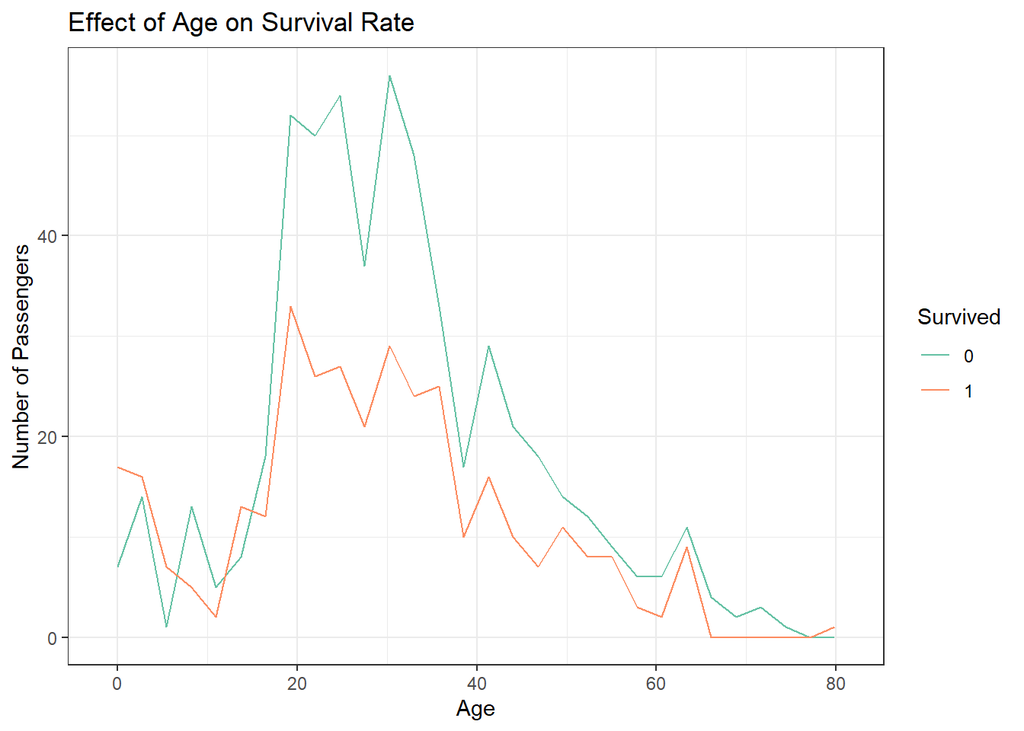

```r
train.clean %>%
  ggplot(aes(x = Age, color = Survived)) +
  geom_line(aes(label=..count..), stat = 'bin') +
  labs(x = "Age",
       y = "Number of Passengers",
       title = "Effect of Age on Survival Rate") +
  theme_bw() + scale_color_brewer(palette = "Set2")
```

**Summary** From the plot, we could conclude that yound passengers have higher survival rate than old passengers.

## FamilySize

Again, utilize WOE and IV to select the variable first.

SibSp

```r
WOETable(X = as.factor(train.clean$SibSp), Y = train.clean$Survived)
```

```
##   CAT GOODS BADS TOTAL       PCT_G       PCT_B        WOE          IV
## 1   0   210  398   608 0.593220339 0.724954463 -0.2005429 0.026418349
## 2   1   112   97   209 0.316384181 0.176684882  0.5825894 0.081387334
## 3   2    13   15    28 0.036723164 0.027322404  0.2957007 0.002779811
## 4   3     4   12    16 0.011299435 0.021857923 -0.6598108 0.006966604
## 5   4     3   15    18 0.008474576 0.027322404 -1.1706364 0.022063953
## 6   5     5    5     5 0.014124294 0.009107468  0.4388015 0.002201391
## 7   8     7    7     7 0.019774011 0.012750455  0.4388015 0.003081947
```

```r
IV(X = as.factor(train.clean$SibSp), Y = train.clean$Survived)
```

```
## [1] 0.1448994
## attr(,"howgood")
## [1] "Highly Predictive"
```

Parch

```r
WOETable(X = as.factor(train.clean$Parch), Y = train.clean$Survived)
```

```
##   CAT GOODS BADS TOTAL       PCT_G       PCT_B        WOE          IV
## 1   0   233  445   678 0.671469741 0.810564663 -0.1882622 0.026186312
## 2   1    65   53   118 0.187319885 0.096539162  0.6628690 0.060175728
## 3   2    40   40    80 0.115273775 0.072859745  0.4587737 0.019458440
## 4   3     3    2     5 0.008645533 0.003642987  0.8642388 0.004323394
## 5   4     4    4     4 0.011527378 0.007285974  0.4587737 0.001945844
## 6   5     1    4     5 0.002881844 0.007285974 -0.9275207 0.004084922
## 7   6     1    1     1 0.002881844 0.001821494  0.4587737 0.000486461
```

```r
IV(X = as.factor(train.clean$Parch), Y = train.clean$Survived)
```

```
## [1] 0.1166611
## attr(,"howgood")
## [1] "Highly Predictive"
```

Family Size [combine:: SibSp + Parch]

```r
WOETable(X = as.factor(train.clean$FamilySize_Cat), Y = train.clean$Survived)
```

```
##      CAT GOODS BADS TOTAL      PCT_G      PCT_B        WOE         IV
## 1 Single   163  374   537 0.47660819 0.68123862 -0.3572179 0.07309765
## 2  Small   169  123   292 0.49415205 0.22404372  0.7910021 0.21365625
## 3  Large    10   52    62 0.02923977 0.09471767 -1.1753709 0.07696082
```

```r
IV(X = as.factor(train.clean$FamilySize_Cat), Y = train.clean$Survived)
```

```
## [1] 0.3637147
## attr(,"howgood")
## [1] "Highly Predictive"
```

Visualization

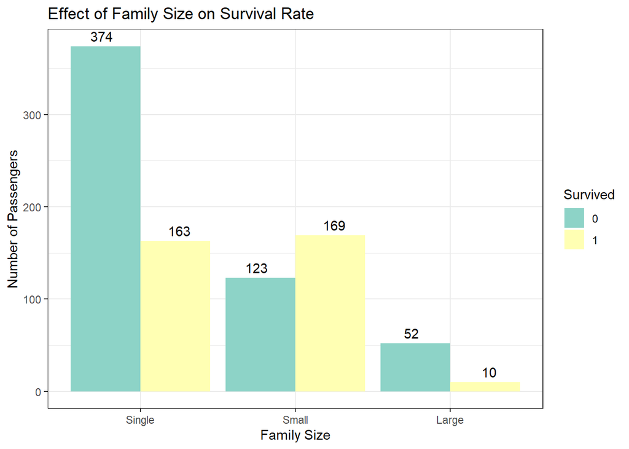

```r
train.clean %>%
  ggplot(aes(x = FamilySize_Cat, y =..count.., fill = Survived)) +
  geom_bar(stat = "count", position = "dodge") +
  labs(x = "Family Size",
       y = "Number of Passengers",
       title = "Effect of Family Size on Survival Rate") +
  theme_bw() + scale_fill_brewer(palette = "Set3") +
  geom_text(stat = "count",
            aes(label = ..count..),
            position = position_dodge(width = 1), vjust = -0.5)
```

**Summary** According to the plot, passengers with small family are the group with the highest survival rate.

## TicketGroup and TicketTyped

As before, apply WOE and IV to select the variable first.

```r
WOETable(X = as.factor(train.clean$TicketGroup), Y = train.clean$Survived)
```

```
##   CAT GOODS BADS TOTAL      PCT_G      PCT_B         WOE           IV
## 1   1   130  351   481 0.37249284 0.63934426 -0.54022525 1.441599e-01
## 2   2    93   88   181 0.26647564 0.16029144  0.50828920 5.397228e-02
## 3   3    66   35   101 0.18911175 0.06375228  1.08733320 1.363075e-01
## 4   4    32   12    44 0.09169054 0.02185792  1.43385577 1.001299e-01
## 5   5     7   14    21 0.02005731 0.02550091 -0.24012066 1.307122e-03
## 6   6     4   15    19 0.01146132 0.02732240 -0.86872932 1.377899e-02
## 7   7     5   19    24 0.01432665 0.03460838 -0.88197455 1.788797e-02
## 8   8     5    8    13 0.01432665 0.01457195 -0.01697711 4.164509e-06
## 9  11     7    7     7 0.02005731 0.01275046  0.45302652 3.310197e-03
```

```r
IV(X = as.factor(train.clean$TicketGroup), Y = train.clean$Survived)
```

```
## [1] 0.470858
## attr(,"howgood")
## [1] "Highly Predictive"
```

```r
WOETable(X = train.clean$TicketType, Y = train.clean$Survived)
```

```
##      CAT GOODS BADS TOTAL      PCT_G     PCT_B        WOE         IV
## 1 Single   130  351   481 0.38011696 0.6393443 -0.5199641 0.13478888
## 2  Small   191  135   326 0.55847953 0.2459016  0.8202864 0.25640338
## 3  Large    21   63    84 0.06140351 0.1147541 -0.6253246 0.03336144
```

```r
IV(X = train.clean$TicketType, Y = train.clean$Survived)
```

```
## [1] 0.4245537
## attr(,"howgood")
## [1] "Highly Predictive"
```

Based on the highest IV criteria, I will select TicketGroup here.

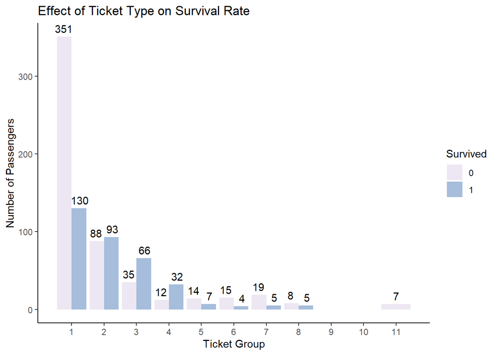

```r
train.clean %>%
  ggplot(aes(x = TicketGroup, y = ..count.., fill = Survived)) +
  geom_bar(stat = "count", position = "dodge") +
  labs(x = "Ticket Group",
       y = "Number of Passengers",
       title = "Effect of Ticket Type on Survival Rate") +
  theme_classic() + scale_fill_brewer(palette = "PuBu") +
  scale_x_continuous(breaks = 1:11) +
  geom_text(stat = "count",
            aes(label = ..count..),
            position = position_dodge(width = 1), vjust = -0.5)
```

**Summary** Based on the result, passengers with ticket group of 2,3,4 have the highest survival rate.

## Fare

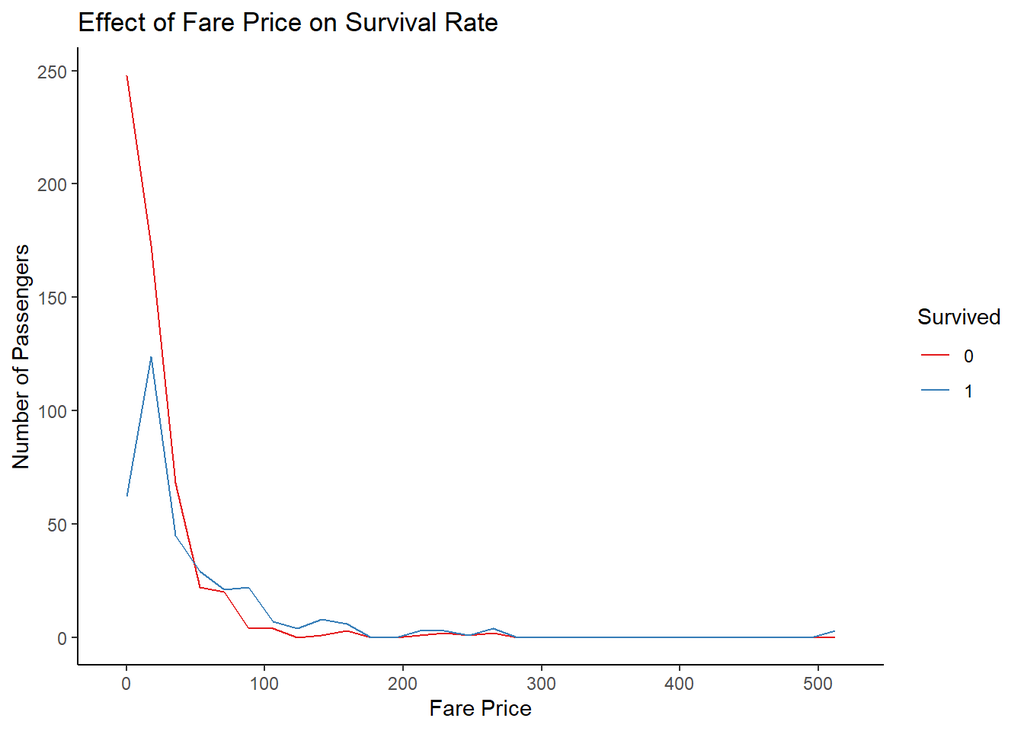

```r
train.clean %>%
  ggplot(aes(x = Fare, color = Survived)) +
  geom_line(aes(label=..count..), stat = 'bin') +
  labs(x = "Fare Price",
       y = "Number of Passengers",
       title = "Effect of Fare Price on Survival Rate") +
  theme_classic() + scale_color_brewer(palette = "Set1")
```

**Summary** Accordingly, when the price is below 200 dollars, the higher the fare price is, the higher the survival rate it, when the price is higher than 200 dollars, there isn’t significant difference.

## Embarked

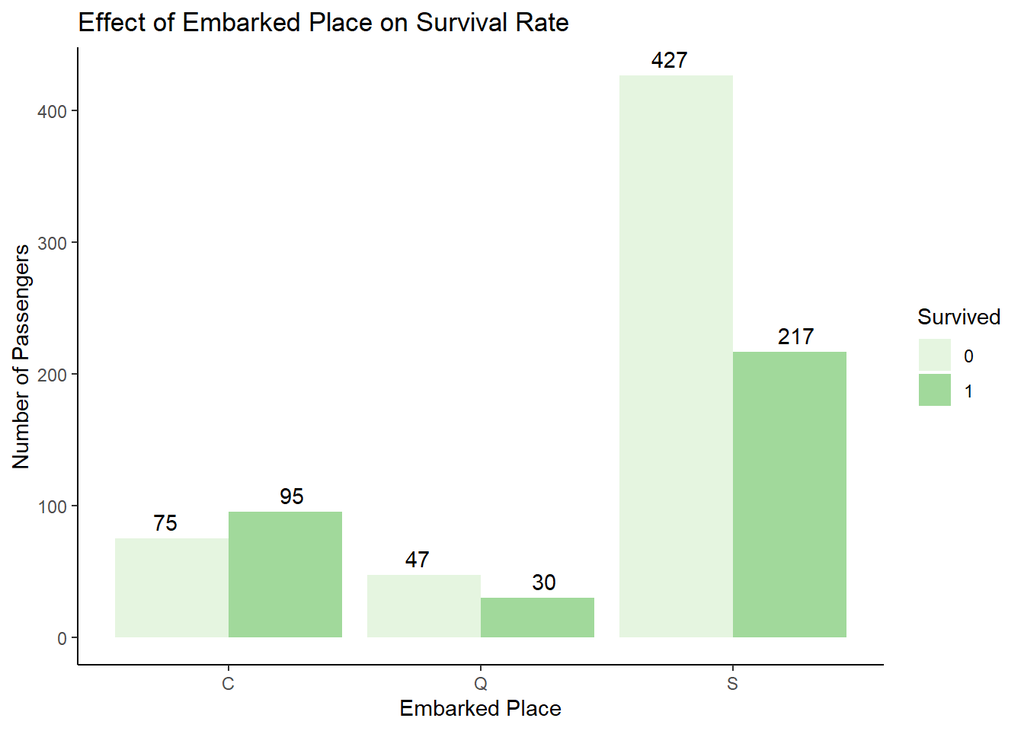

```r
train.clean %>%
  ggplot(aes(x = Embarked, y = ..count.., fill = Survived)) +
  geom_bar(stat = "count", position = "dodge") +
  labs(x = "Embarked Place",
       y = "Number of Passengers",
       title = "Effect of Embarked Place on Survival Rate") +
  theme_classic() + scale_fill_brewer(palette = "RedGs") +
  geom_text(stat = "count",
            aes(label = ..count..),
            position = position_dodge(width = 1), vjust = -0.5)
```

**Summary** Based on the plot, the survival rate for passengers embarked on C is the highest, while the survival rate for passengers embarked on S is the lowest.

```r
WOETable(X = train.clean$Embarked, Y = train.clean$Survived)
```

```
##   CAT GOODS BADS TOTAL     PCT_G     PCT_B         WOE           IV
## 1   C    95   75   170 0.2777778 0.1366120  0.70967648 1.001820e-01
## 2   Q    30   47    77 0.0877193 0.0856102  0.02433748 5.133014e-05
## 3   S   217  427   644 0.6345029 0.7777778 -0.20359896 2.917061e-02
```

```r
IV(X = train.clean$Embarked, Y = train.clean$Survived)
```

```
## [1] 0.129404
## attr(,"howgood")
## [1] "Highly Predictive"
```

Accordingly, Embarked could be regarded as one of the features used to predict the survival because of the high IV value.

```r
train.final <- train.clean %>%
  select_all()

test.final <- test.clean %>%
  select_all()

colSums(is.na(train.final))
```

```
##       Survived         Pclass           Name            Sex            Age
##              0              0              0              0              0
##          SibSp          Parch         Ticket           Fare       Embarked
##              0              0              0              0              0
##   Age_Category          Title     FamilySize FamilySize_Cat    TicketGroup
##              0              0              0              0              0
##     TicketType
##              0
```

```r
colSums(is.na(test.final))
```

```
##         Pclass           Name            Sex            Age          SibSp
##              0              0              0              0              0
##          Parch         Ticket           Fare       Embarked   Age_Category
##              0              0              0              0              3
##          Title     FamilySize FamilySize_Cat    TicketGroup     TicketType
##              0              0              0              0              0
```

# Correlations Numeric Independent Variables

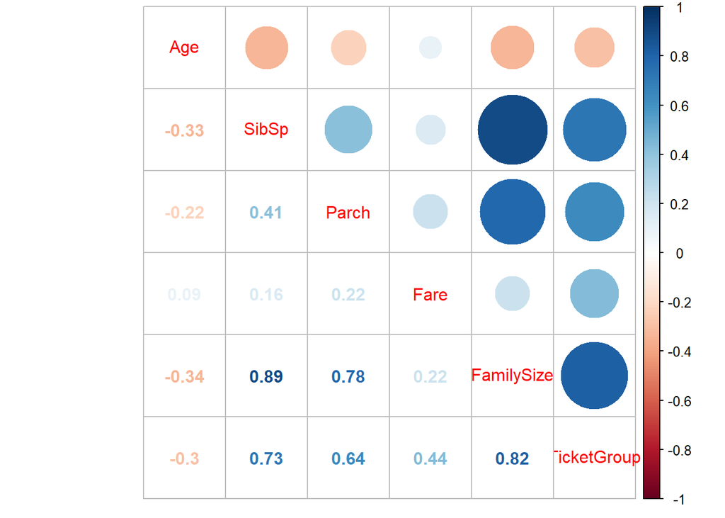

```r
train.final %>%
  select_if(is.numeric) %>%
  cor() %>%
  corrplot.mixed()
```

# Build Class Model

## Logistic Regression

```r
titanic.null <- glm(Survived ~ 1, data = train.final, family = 'binomial')
titanic.full <- glm(Survived ~ ., data = train.final, family = 'binomial')
titanic.step <- step(titanic.null, scope = list(lower = titanic.null, upper = full_data),
                     direction = "both")
```

```
## Start:  AIC=1188.66
## Survived ~ 1
##
##                   Df Deviance     AIC
## + Title            4   886.64  896.64
## + Sex              1   917.80  921.80
## + TicketType       2  1098.09 1104.09
## + FamilySize_Cat   2  1111.56 1117.56
## + Fare             1  1117.57 1121.57
## + Embarked         2  1159.30 1165.30
## + Age_Category     3  1173.14 1181.14
## + Age              1  1179.78 1183.78
## + Parch            1  1180.84 1184.84
## + TicketGroup      1  1182.96 1186.96
## <none>                1186.66 1188.66
## + SibSp            1  1185.51 1189.51
## + FamilySize       1  1186.41 1190.41
## + Ticket         680   166.47 1528.47
## + Name           890     0.00 1782.00
##
## Step:  AIC=896.64
## Survived ~ Title
##
##                   Df Deviance     AIC
## + FamilySize_Cat   2   813.72  827.72
## + TicketType       2   834.02  848.02
## + FamilySize       1   841.55  853.55
## + SibSp            1   846.14  858.14
## + Fare             1   855.86  867.86
## + Embarked         2   865.42  879.42
## + Parch            1   868.49  880.49
## + TicketGroup      1   873.60  885.60
## + Sex              1   881.07  893.07
## + Age              1   883.18  895.18
## <none>                 886.64  896.64
## + Age_Category     3   880.88  896.88
## - Title            4  1186.66 1188.66
## + Ticket         680    28.22 1398.22
## + Name           886     0.00 1782.00
##
```

[output cut: 126 more lines]

```
## <none>                 751.55  773.55
## + Age_Category     3   746.14  774.14
## + FamilySize_Cat   2   748.60  774.60
## + Age              1   750.95  774.95
## + Embarked         2   748.95  774.95
## + SibSp            1   751.01  775.01
## + Parch            1   751.01  775.01
## - Sex              1   755.45  775.45
## - TicketGroup      1   759.26  779.26
## - FamilySize       1   767.29  787.29
## - TicketType       2   781.55  799.55
## - Fare             1   795.80  815.80
## - Title            4   819.64  833.64
## + Name           880     0.00 1782.00
## + Ticket         677  1009.22 2385.22
```

```r
summary(titanic.step)
```

```
##
## Call:
## glm(formula = Survived ~ Title + Fare + Sex + TicketType + TicketGroup +
##     FamilySize, family = "binomial", data = train.final)
##
## Deviance Residuals:
##     Min       1Q   Median       3Q      Max
## -2.5614  -0.5430  -0.5256   0.6025   2.2719
##
## Coefficients:
##                   Estimate Std. Error z value Pr(>|z|)
## (Intercept)       0.856950   0.273645   3.132  0.00174 **
## TitleMaster      16.309220 590.201593   0.028  0.97795
## TitleMr          12.371512 590.201411   0.021  0.98328
## TitleMrs          0.579094   0.333024   1.739  0.08205 .
## TitleUnordinary  12.533351 590.201120   0.021  0.98306
## Fare              0.019189   0.003331   5.760 8.42e-09 ***
## Sexmale         -15.313367 590.201359  -0.026  0.97930
## TicketTypeSmall  -0.492973   0.343579  -1.435  0.15134
## TicketTypeLarge  -4.265632   1.028351  -4.148 3.35e-05 ***
## TicketGroup       0.506888   0.177931   2.849  0.00439 **
## FamilySize       -0.463403   0.112799  -4.108 3.99e-05 ***
## ---
## Signif. codes:  0 '***' 0.001 '**' 0.01 '*' 0.05 '.' 0.1 ' ' 1
##
## (Dispersion parameter for binomial family taken to be 1)
##
##     Null deviance: 1186.66  on 890  degrees of freedom
## Residual deviance:  751.55  on 880  degrees of freedom
## AIC: 773.55
##
## Number of Fisher Scoring iterations: 13
```

```r
ClassLog(titanic.step, train.final$Survived, cut = .5)
```

```
## $rawtab
##        resp
##           0   1
##   FALSE 484  89
##   TRUE   65 253
##
## $classtab
##        resp
##                 0         1
##   FALSE 0.8816029 0.2602339
##   TRUE  0.1183971 0.7397661
##
## $overall
## [1] 0.8271605
##
## $mcFadden
## [1] 0.3666625
```

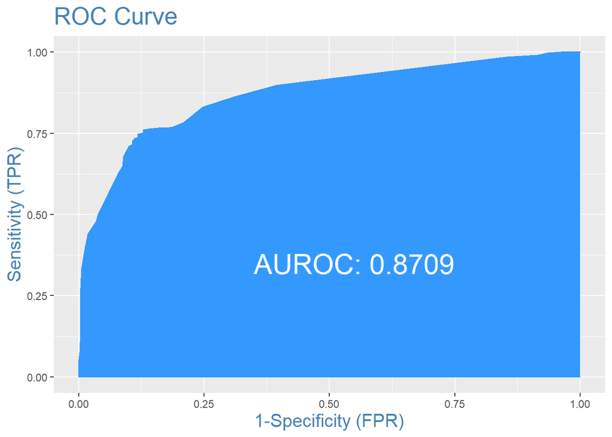

```r
predicted <- plogis(predict(titanic.step, train.final))
plotROC(train.final$Survived, predicted)
```

```r
(optCutOff <- optimalCutoff(train.final$Survived, predicted))
```

```
## [1] 0.4399998
```

```r
ClassLog(titanic.step, train.final$Survived, cut = .65)
```

```
## $rawtab
##        resp
##           0   1
##   FALSE 491  98
##   TRUE   58 244
##
## $classtab
##        resp
##                 0         1
##   FALSE 0.8943534 0.2865497
##   TRUE  0.1056466 0.7134503
##
## $overall
## [1] 0.8249158
##
## $mcFadden
## [1] 0.3666625
```

Predict on the test data:

```r
pred.logistic <- predict(titanic.step, test.final, type = "response")
pred.logistic <- ifelse(pred.logistic > 0.65, 1, 0)
```

## Random Forest

```r
set.seed(1)
titanicRF <- randomForest(Survived ~., data = train.final)
confusionMatrix(titanicRF$predicted, train.final$Survived,positive = "1")
```

```
## Confusion Matrix and Statistics
##
##           Reference
## Prediction   0   1
##          0 493  88
##          1  56 254
##
##                Accuracy : 0.8384
##                  95% CI : (0.8125, 0.862)
##     No Information Rate : 0.6162
##     P-Value [Acc > NIR] : < 2.2e-16
##
##                   Kappa : 0.6522
##
##  Mcnemar's Test P-Value : 0.009785
##
##             Sensitivity : 0.7427
##             Specificity : 0.8980
##          Pos Pred Value : 0.8194
##          Neg Pred Value : 0.8485
##              Prevalence : 0.3838
##          Detection Rate : 0.2851
##    Detection Prevalence : 0.3479
##       Balanced Accuracy : 0.8203
##
##        'Positive' Class : 1
##
```

Predict on the test data:

```r
pred.rf <- predict(titanicRF, test.final, type = "response")
```

# Prediction Accuracy

**Summary** 1. Logistic Regression - 0.7751 2. Accuracy with Random Forest - 0.7895

# Summary

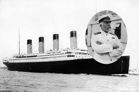

```r
knitr::include_graphics("image/intro.jfif")
```